[figure not shown]

### *Student Version*

A data analytics tool to inspect energy data frames and perform complex analysis  
[**Explore the docs »**](https://github.com/RobertoChiosa/BAEDA_data_analytics)  
[View Demo](https://github.com/RobertoChiosa/BAEDA_data_analytics) · [Report Bug](https://github.com/RobertoChiosa/BAEDA_data_analytics/issues) · [Request Feature](https://github.com/RobertoChiosa/BAEDA_data_analytics/issues)

## About The Project

This project consists in the design and development of interactive dashboards for the visualization of energy data. In particular, we propose the creation of the “Energy data analytics dashboard” that allows to interact with the data in a deeper way by modifying the hyperparameters of the code, giving the user great flexibility in the exploration. In addition, we introduced ad hoc interactive apps that can perform advanced data analysis workflows, ranging from automatic Anomaly Detection and Diagnosis (ADD), Fault Detection and Diagnosis (FDD) and Automated System Optimization (ASO).

[figure not shown]

### Built With

- [RStudio](https://rstudio.com/)
- [Shiny](https://shiny.rstudio.com/)

## Getting Started

First of all you need to have RStudio installed on your computer. Then to get a local copy up and running the dashboard follow these simple steps.

Clone the guithub repository on your computer:

1. In RStudio, start a new Project by following this path *File > New Project > Version Control > Git*;
2. In “Repository URL”", paste this URL `https://github.com/RobertoChiosa/BAEDA_data_analytics`;
3. Accept the default project directory name which coincides with the GitHub repo name;
4. Chose a local path to save the repository on computer;
5. Click “Create Project”.

## Roadmap

See the [open issues](https://github.com/RobertoChiosa/BAEDA_data_analytics/issues) for a list of proposed features (and known issues).

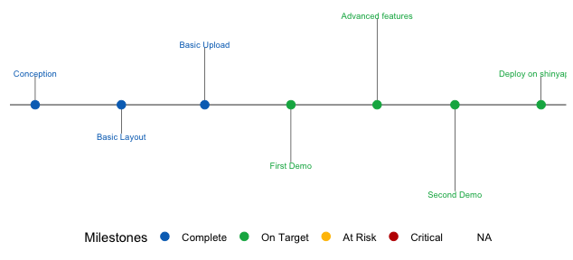

## Contributing

Contributions are what make the open source community such an amazing place to be learn, inspire, and create. Any contributions you make are **greatly appreciated**.

1. Fork the Project
2. Create your Feature Branch (`git checkout -b feature/AmazingFeature`)
3. Commit your Changes (`git commit -m 'Add some AmazingFeature'`)
4. Push to the Branch (`git push origin feature/AmazingFeature`)
5. Open a Pull Request

## Contact

Roberto Chiosa - roberto.chiosa@gmail.com

Project Link: https://github.com/RobertoChiosa/BAEDA_data_analytics